# Curso de Inferencia

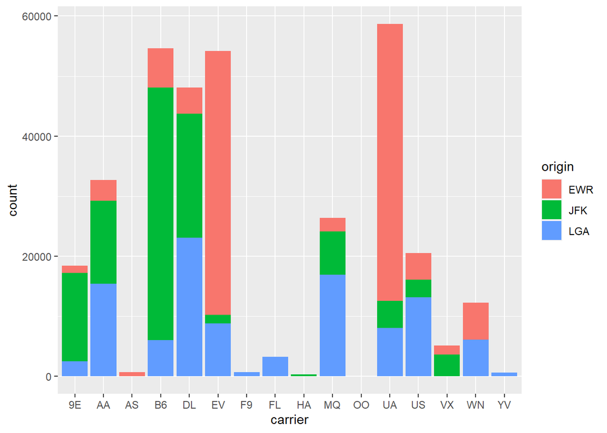

```r
flights |>
ggplot(aes(x = carrier, fill = origin)) +
  geom_bar()
```

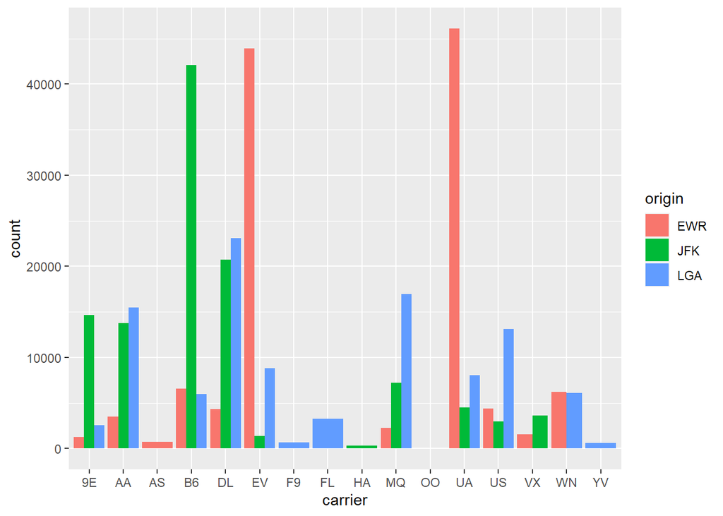

```r
flights |>
ggplot(aes(x = carrier, fill = origin)) +
  geom_bar(position = "dodge")
```

*Facetas*

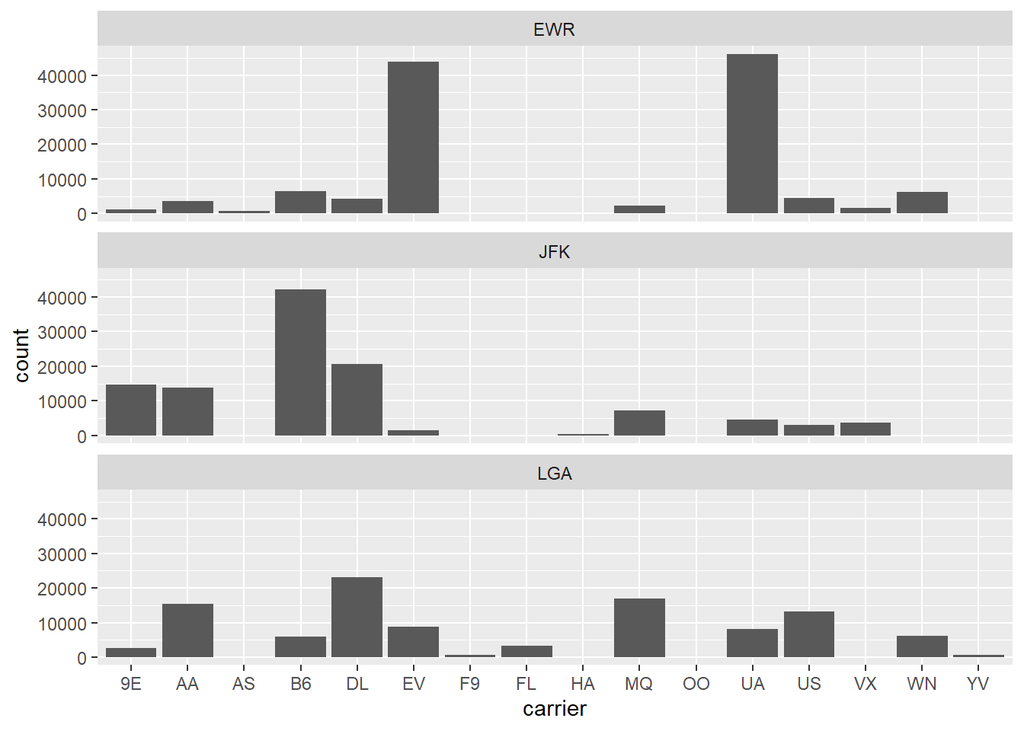

```r
flights |>
ggplot(aes(x = carrier)) +
  geom_bar(position = "dodge") +
  facet_wrap(~ origin, ncol = 1)
```

### Muestreo

#### Muestreo aleatorio simple

- Universo

```r
set.seed(1234)
universo <- tibble(
     color = c(rep("roja", 625), rep("blanca", 2500 - 625))
     ) |>
     mutate(id = row_number()) |>
     relocate(id)

knitr::kable(universo[1:10,])
```

| id | color |
| --- | --- |
| 1 | roja |
| 2 | roja |
| 3 | roja |
| 4 | roja |
| 5 | roja |
| 6 | roja |
| 7 | roja |
| 8 | roja |
| 9 | roja |
| 10 | roja |

Para $n=25$

```r
# 1.a) Selección de 1000 muestras de tamaño 25

n25 <- universo |>
       rep_sample_n(size = 25, reps = 1000)


# 1.b) Estimación puntual

prop25 <- n25 |>
          count(replicate, color) |>
          group_by(replicate) |>
          mutate(prop = n / sum(n)) |>
          filter(color == "roja")

# 1.c) Histograma

g25 <- prop25 |>
       ggplot(aes(x = prop)) +
       geom_histogram(binwidth = 0.05, color = "white")
```

Para $n=50$

```r
#########  n=50
# 1.a) Selección de 1000 muestras de tamaño 50

n50 <- universo |>
       rep_sample_n(size = 50, reps = 1000)


# 1.b) Estimación puntual

prop50 <- n50 |>
          count(replicate, color) |>
          group_by(replicate) |>
          mutate(prop = n / sum(n)) |>
          filter(color == "roja")

# 1.c) Histograma

g50 <- prop50 |>
       ggplot(aes(x = prop)) +
       geom_histogram(binwidth = 0.05, color = "white")
```

Para $n=100$

```r
#########  n=100
# 1.a) Selección de 1000 muestras de tamaño 100

n100 <- universo |>
       rep_sample_n(size = 100, reps = 1000)

# 1.b) Estimación puntual

prop100 <- n100 |>
           count(replicate, color) |>
           group_by(replicate) |>
           mutate(prop = n / sum(n)) |>
           filter(color == "roja")

# 1.c) Histograma

g100 <- prop100 |>
        ggplot(aes(x = prop)) +
        geom_histogram(binwidth = 0.05, color = "white")
```

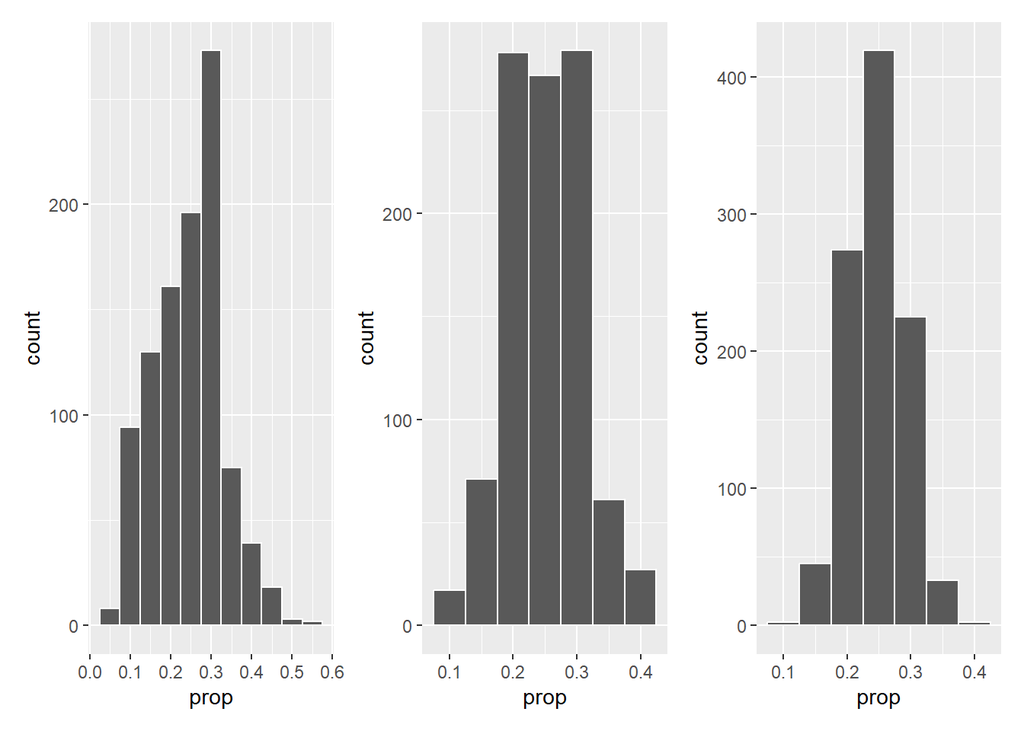

```r
g25 | g50 | g100
```

*Variación muestral*

```r
#### variación muestral
sd(prop25$prop)
```

```
## [1] 0.0845627
```

```r
sd(prop50$prop)
```

```
## [1] 0.05966441
```

```r
sd(prop100$prop)
```

```
## [1] 0.04343213
```

### Distribuciones Muestrales

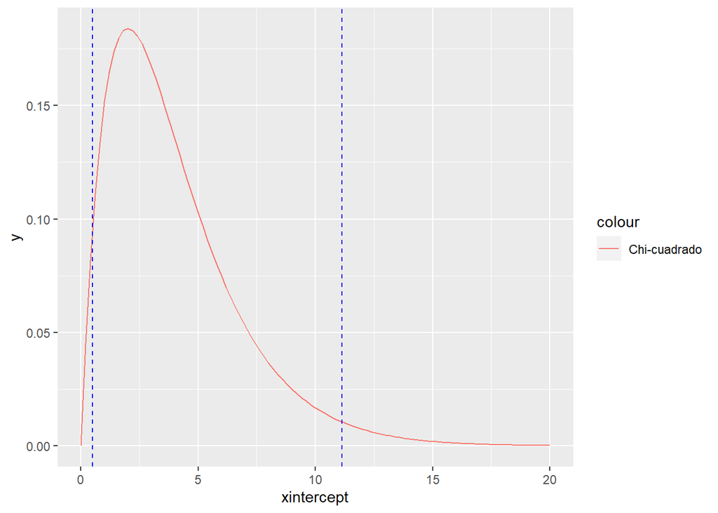

```r
ggplot() +
    geom_function(aes(color = "Chi-cuadrado"),
                  fun = dchisq, args = list(df = 4)) +
    xlim(0,20) +
    geom_vline(xintercept = qchisq(0.025, df = 4), linetype = 2, color = "blue") +
    geom_vline(xintercept = qchisq(0.975, df = 4), linetype = 2, color = "blue")
```

### Intervalos de confianza

#### Medias

*Una Muestra*

-El contenido de ácido sulfúrico de 7 contenedores similares es de 9.8, 10.2, 10.4, 9.8, 10.0, 10.2, y 9.6 litros. Calcule un intervalo de confianza del 95% para el contenido promedio de todos los contenedores suponiendo una distribución aproximadamente normal.

```r
x <- c(9.8, 10.2, 10.4, 9.8, 10.0, 10.2, 9.6)

t.test(x, conf.level = 0.95)
```

```
##
##  One Sample t-test
##
## data:  x
## t = 93.541, df = 6, p-value = 1.006e-10
## alternative hypothesis: true mean is not equal to 0
## 95 percent confidence interval:
##   9.738414 10.261586
## sample estimates:
## mean of x
##        10
```

*Diferencia de medias*

- Considere los datos del ejercicio 18. Argumente la decisión de la varianza igual o diferente.

```r
datos <- tibble(
Cond1 = c(55.6,56.1,61.8,55.9,51.4,59.9,54.3,62.8,58.5,55.8,58.3,60.2,54.2,50.1,57.1,57.5,63.6,59.3,60.9,61.8),
Cond2 = c(55.1,43.5,51.2,46.2,56.7,52.5,53.5,60.5,52.1,47.0,53.0,53.8,51.6,53.6,42.9,52.0,55.1,57.1,62.8,54.8)
) %>%
pivot_longer(cols = starts_with("Cond"), names_to = "Cond", values_to = "tiempo")  %>%
  mutate(Condicion = ifelse(Cond == "Cond1", 1, 2))
```

Intervalo de confianza

```r
m1 <- aov(tiempo~Condicion, data= datos)
summary(m1)
```

```
##             Df Sum Sq Mean Sq F value   Pr(>F)
## Condicion    1  250.5  250.50   13.02 0.000887 ***
## Residuals   38  731.4   19.25
## ---
## Signif. codes:  0 '***' 0.001 '**' 0.01 '*' 0.05 '.' 0.1 ' ' 1
```

```r
t.test(tiempo~Condicion, data=datos, var.equal = TRUE)
```

```
##
##  Two Sample t-test
##
## data:  tiempo by Condicion
## t = 3.6077, df = 38, p-value = 0.0008869
## alternative hypothesis: true difference in means between group 1 and group 2 is not equal to 0
## 95 percent confidence interval:
##  2.196537 7.813463
## sample estimates:
## mean in group 1 mean in group 2
##          57.755          52.750
```

```r
t.test(tiempo~Condicion, data=datos, var.equal = FALSE)
```

```
##
##  Welch Two Sample t-test
##
## data:  tiempo by Condicion
## t = 3.6077, df = 34.798, p-value = 0.0009598
## alternative hypothesis: true difference in means between group 1 and group 2 is not equal to 0
## 95 percent confidence interval:
##  2.188025 7.821975
## sample estimates:
## mean in group 1 mean in group 2
##          57.755          52.750
```

#### Proporciones

*Intervalo de confianza para la Proporción*

```r
datap <- datos %>%
         mutate(dico = ifelse(tiempo > 60, 1, 0))

Exitos <- sum(datap$dico)
n <- nrow(datap)
```

```r
prop.test(x = Exitos, n = n)
```

```
##
##  1-sample proportions test with continuity correction
##
## data:  Exitos out of n, null probability 0.5
## X-squared = 13.225, df = 1, p-value = 0.0002762
## alternative hypothesis: true p is not equal to 0.5
## 95 percent confidence interval:
##  0.09614522 0.36137437
## sample estimates:
##   p
## 0.2
```

*Diferencia de proporciones*

```r
table(datap$dico, datap$Condicion)
```

```
##
##      1  2
##   0 14 18
##   1  6  2
```

En la condición 1 tenemos 6 éxitos, mientras que en la condición 2 tenemos 2 éxitos.

```r
prop.test(c(6,2), c(20, 20), correct = FALSE, conf.level = 0.95)
```

```
##
##  2-sample test for equality of proportions without continuity correction
##
## data:  c(6, 2) out of c(20, 20)
## X-squared = 2.5, df = 1, p-value = 0.1138
## alternative hypothesis: two.sided
## 95 percent confidence interval:
##  -0.04004558  0.44004558
## sample estimates:
## prop 1 prop 2
##    0.3    0.1
```

### Bootstrap

#### Intervalo para $\mu$

```r
library(infer)
```

El flujo de trabajo de `infer` tiene unos pasos simples para usarse en el entorno `tidyverse`.

1. Indique el conjunto de datos
2. Especifique las variables que se usarán en la inferencia, para ello use la función `specify(formula = y ~ x)`.

Note que este paso es similar al verbo `dplyr::select()` y además el flujo de trabajo identifica el tipo de variable.

```r
datap %>%
  specify(response = tiempo) %>%
  head()
```

```
## # A tibble: 6 × 1
##   tiempo
##    <dbl>
## 1   55.6
## 2   55.1
## 3   56.1
## 4   43.5
## 5   61.8
## 6   51.2
```

Ahora usemos una especificación de una formula, esto es más usual y universal. El caso anterior puede usarse como `specify(formula = tiempo ~ NULL)`

```r
datap %>%
  specify(formula = tiempo ~ NULL) %>%
  glimpse()
```

```
## Rows: 40
## Columns: 1
## $ tiempo <dbl> 55.6, 55.1, 56.1, 43.5, 61.8, 51.2, 55.9, 46.2, 51.4, 56.7, 59.…
```

3. El paso `generate()` se usa para crear las réplicas. Note como tenemos ahora 400 mil registros y una variable de réplica.

```r
datap %>%
  specify(formula = tiempo ~ NULL) %>%
  generate(reps = 10000, type = "bootstrap") %>%
  glimpse()
```

```
## Rows: 400,000
## Columns: 2
## Groups: replicate [10,000]
## $ replicate <int> 1, 1, 1, 1, 1, 1, 1, 1, 1, 1, 1, 1, 1, 1, 1, 1, 1, 1, 1, 1, …
## $ tiempo    <dbl> 55.1, 43.5, 54.8, 61.8, 42.9, 57.5, 53.5, 57.5, 54.3, 60.9, …
```

4. Paso `calculate()`. Se toma cada réplica y se calcula el valor de la estadística. Lo almacenamos en `dist.boot`

```r
dist.boot <- datap %>%
  specify(formula = tiempo ~ NULL) %>%
  generate(reps = 10000, type = "bootstrap") %>%
  calculate(stat = "mean") %>%
  glimpse()
```

```
## Rows: 10,000
## Columns: 2
## $ replicate <int> 1, 2, 3, 4, 5, 6, 7, 8, 9, 10, 11, 12, 13, 14, 15, 16, 17, 1…
## $ stat      <dbl> 54.7625, 55.8175, 55.1050, 54.7650, 55.3500, 54.1775, 56.755…
```

5. Paso en que se visualiza la distribución bootstrap del estimador.

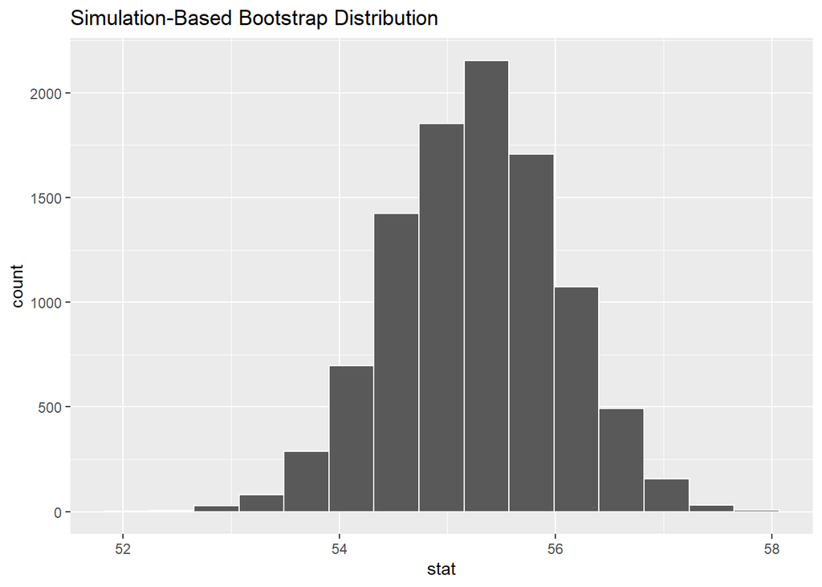

```r
visualise(dist.boot)
```

6. Calcular el intervalo de confianza o visualizarlo.

*Calcular el intervalo*

Puede usa `type = "percentile"` para el método del percentil, o `type = "se"` para el error estándar.

```r
(ic_perc <- dist.boot %>%
           get_confidence_interval(level = 0.95, type = "percentile"))
```

```
## # A tibble: 1 × 2
##   lower_ci upper_ci
##      <dbl>    <dbl>
## 1     53.8     56.8
```

*Visualizar el intervalo*

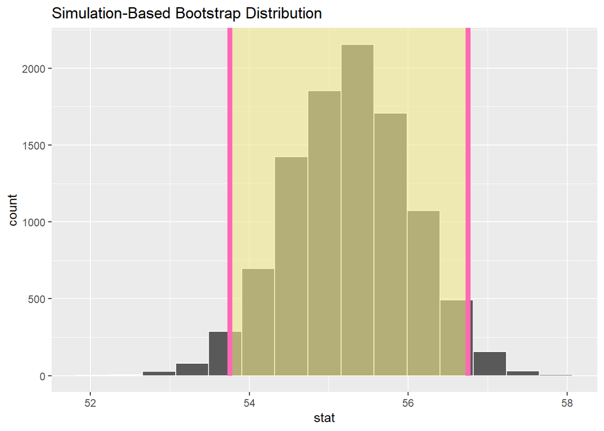

```r
visualize(dist.boot) +
  shade_ci(endpoints = ic_perc, color = "hotpink", fill = "khaki")
```

*Intervalo usando el error estándar*

```r
(se <- dist.boot %>%
      get_confidence_interval(type = "se", point_estimate = mean(datap$tiempo)))
```

```
## Using `level = 0.95` to compute confidence interval.
```

```
## # A tibble: 1 × 2
##   lower_ci upper_ci
##      <dbl>    <dbl>
## 1     53.7     56.8
```

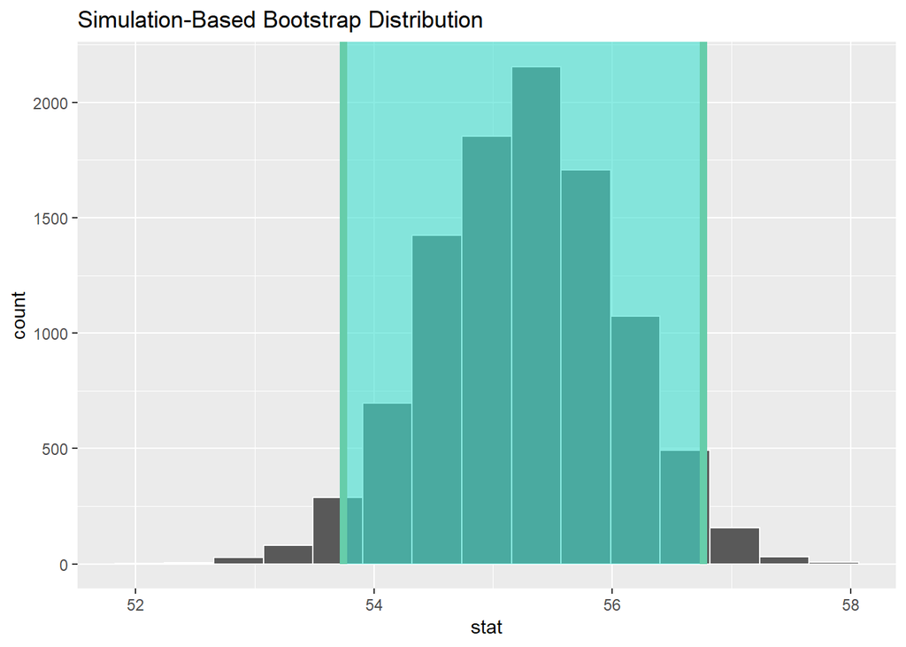

```r
visualize(dist.boot) +
  shade_ci(endpoints = se)
```

Podemos agregar la estimación puntual con capas como en `ggplot()`

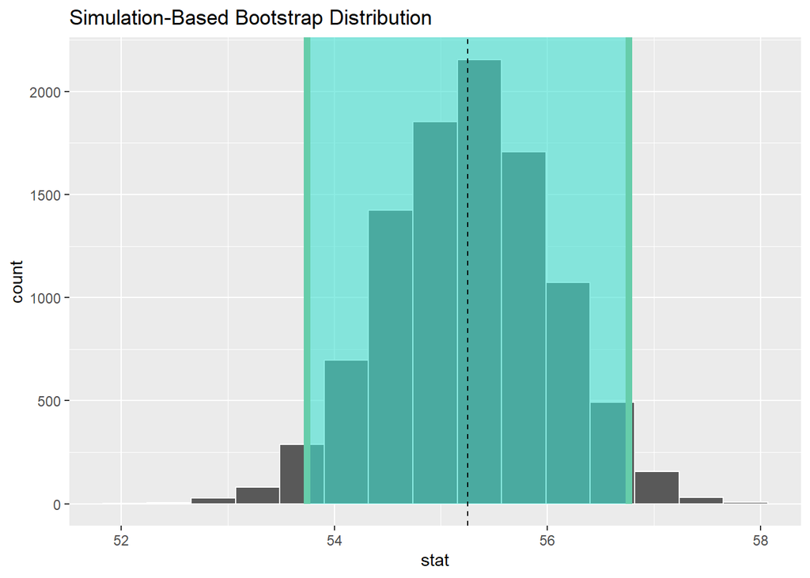

```r
dist.boot %>%
visualize() +
  shade_ci(endpoints = se) +
  geom_vline(xintercept = mean(datap$tiempo), linetype = 2)
```

#### Intervalo para $p$

En nuestro conjunto de datos `datap` tenemos una columna que indica si hubo éxito o fracaso y la denominamos `dico`. La vamos a convertir en un factor con niveles. Por qué es necesario hacer esto?

```r
pest <- Exitos/n
datap$dico <- factor(datap$dico, levels = 0:1, labels = c("<=60",">60"))
```

Indicaremos en el procedimiento cuál es la variable de resultado y el valor de éxito que nos interesa.

```r
datap %>%
  specify(response = dico, success = ">60")
```

```
## # A tibble: 40 × 1
##    dico
##    <fct>
##  1 <=60
##  2 <=60
##  3 <=60
##  4 <=60
##  5 >60
##  6 <=60
##  7 <=60
##  8 <=60
##  9 <=60
## 10 <=60
## # ℹ 30 more rows
```

Ahora vamos con los pasos 3 y 4.

```r
res <- datap %>%
       specify(response = dico, success = ">60") %>%
       generate(reps = 1000, type = "bootstrap") %>%
       calculate(stat = "prop")
```

Puede extraer solo el resultado del intervalo

```r
(ic_perc <- res %>%
        get_confidence_interval(level = 0.95, type = "percentile"))
```

```
## # A tibble: 1 × 2
##   lower_ci upper_ci
##      <dbl>    <dbl>
## 1    0.075    0.325
```

Recuerde que en el intervalo con el método del error estándar le debe indicar el valor de la estimación puntual

```r
(ic_ee <- res %>%
    get_ci(level = 0.95, type = "se", point_estimate = pest))
```

```
## # A tibble: 1 × 2
##   lower_ci upper_ci
##      <dbl>    <dbl>
## 1   0.0739    0.326
```

Puede visualizar el intervalo de la siguiente manera, agregando capas como en ggplot:

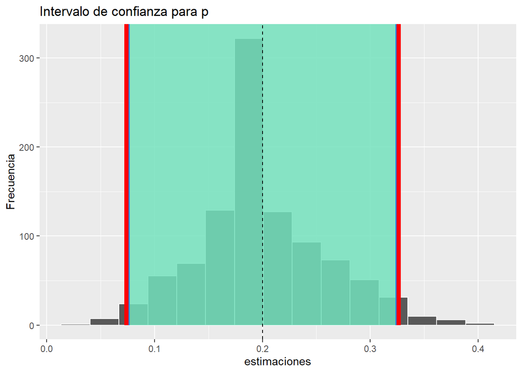

```r
res %>%
  visualise() +
  shade_ci(endpoints = ic_perc, color = "blue", fill = "khaki") +
  shade_ci(endpoints = ic_ee, color = "red") +
  geom_vline(xintercept = pest, linetype = 2) +
  labs(title = "Intervalo de confianza para p",
       x = "estimaciones", y = "Frecuencia")
```

#### $p_1-p_2$

Considere el problema 18 del taller sobre los tiempos de secado. Construya un intervalo de confianza del 98% para la diferencia de proporciones de hojas cubiertas de poliuretano con tiempos de secado mayores que 55.

```r
datadp <- datos %>%
          mutate(x = ifelse(tiempo > 55, 1, 0))

n1e <- sum(datadp[datadp$Condicion == 1, "x"])
n2e <- sum(datadp[datadp$Condicion == 2, "x"])

p1e <- n1e/20
p2e <- n2e/20
```

La variable debe ser categórica

```r
datadp$x <- factor(datadp$x, levels = 0:1,
                   labels = c("Tiempo<=50", "Tiempo>50"))

datadp$Condicion <- as.factor(datadp$Condicion)
```

Realizamos el procedimiento. Tenga en cuenta que el el paso `calculate` debe incluir el argumento `order=c()` con el orden de los niveles de su variable categórica. En nuestro caso será $p_1-p_2$.

```r
res <- datadp %>%
  specify(formula = x~Condicion, success = "Tiempo>50") %>%
  generate(reps = 100, type = "bootstrap") %>%
  calculate(stat = "diff in props", order = c("1", "2"))
```

Intervalos de confianza

```r
ic_dp_perc <- res %>%
              get_ci(level = 0.98, type = "percentile")


ic_dp_ee <- res %>%
              get_ci(level = 0.98, type = "se", point_estimate = p1e - p2e)
```

Ahora visualizamos el intervalo

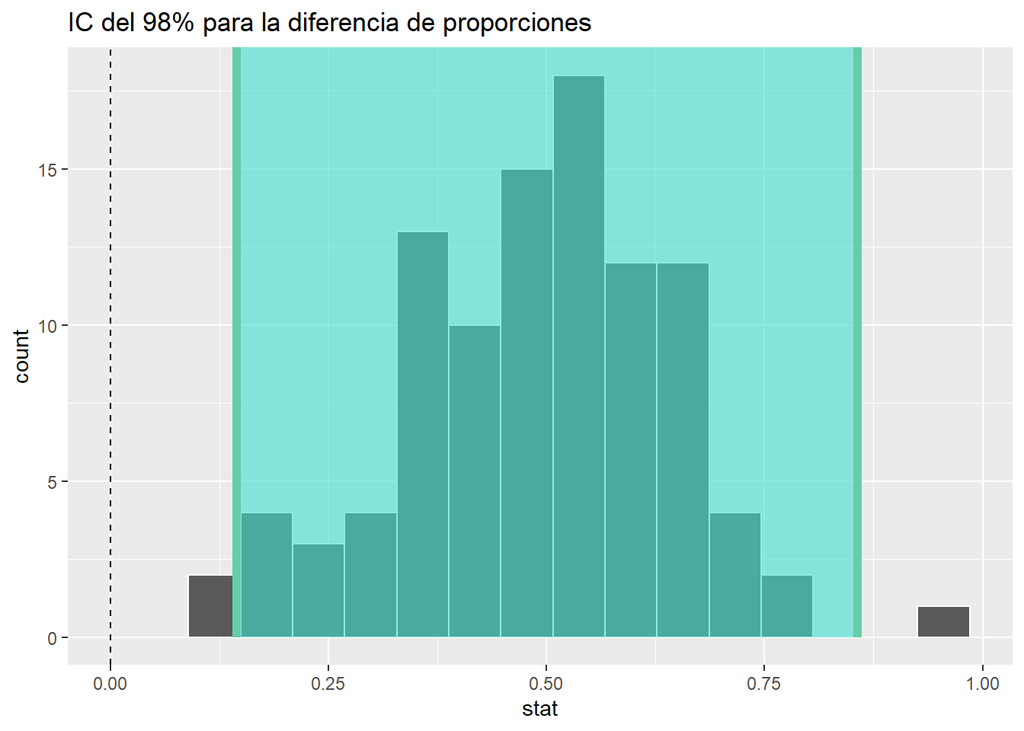

```r
res %>%
  visualise() +
  shade_ci(endpoints = ic_dp_ee) +
  geom_vline(xintercept = 0, linetype = 2) +
  labs(title = "IC del 98% para la diferencia de proporciones")
```

#### $\mu_1 - \mu_2$

A partir del punto 18 del taller se calculará el intervalo de confianza del 98% para la diferencia de medias.

```r
res <- datos %>%
  mutate(Condicion = factor(Condicion, levels = 1:2, labels = c("c1", "c2"))) %>%
  specify(formula = tiempo ~ Condicion) %>%
  generate(reps = 1000, type = "bootstrap") %>%
  calculate(stat = "diff in means", order = c("c1", "c2"))
```

La estimación puntual puede ser obtenida al eliminar la línea del `generate`

```r
est.puntual <- datos %>%
  mutate(Condicion = factor(Condicion, levels = 1:2, labels = c("c1", "c2"))) %>%
  specify(formula = tiempo ~ Condicion) %>%
  calculate(stat = "diff in means", order = c("c1", "c2"))
```

Alternativamente puede usar:

```r
est.puntual <- datos %>%
  mutate(Condicion = factor(Condicion, levels = 1:2, labels = c("c1", "c2"))) %>%
  observe(formula = tiempo ~ Condicion,
          stat = "diff in means",
          order = c("c1", "c2"))
```

```r
ic_dm_perc <- res %>%
              get_ci(level = 0.98, type = "percentile")


ic_dm_ee <- res %>%
              get_ci(level = 0.98, type = "se", point_estimate = est.puntual)
```

Ahora visualizamos el intervalo

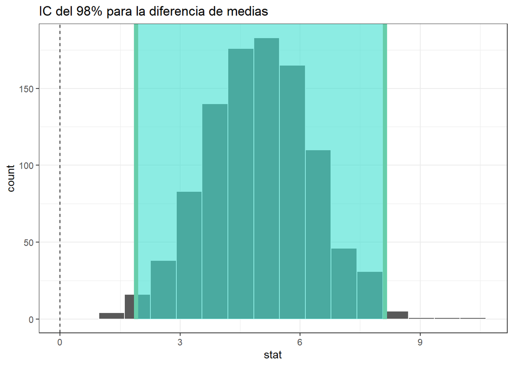

```r
res %>%
  visualise() +
  shade_ci(endpoints = ic_dm_ee) +
  geom_vline(xintercept = 0, linetype = 2) +
  labs(title = "IC del 98% para la diferencia de medias") + theme_bw()
```

```r
estima.rep <- datos %>%
  specify(formula = tiempo ~ NULL) %>%
  generate(reps = 1000, type = "bootstrap") %>%
  calculate(stat = "sd")
```

```r
estima.s <- datos %>%
  observe(formula = tiempo ~ NULL, stat = "sd")
```

```r
ic_s_perc <- estima.rep %>%
            get_ci(type = "percentile", level = 0.95)


ic_s_ee <- estima.rep %>%
              get_ci(type = "se", point_estimate = estima.s)
```

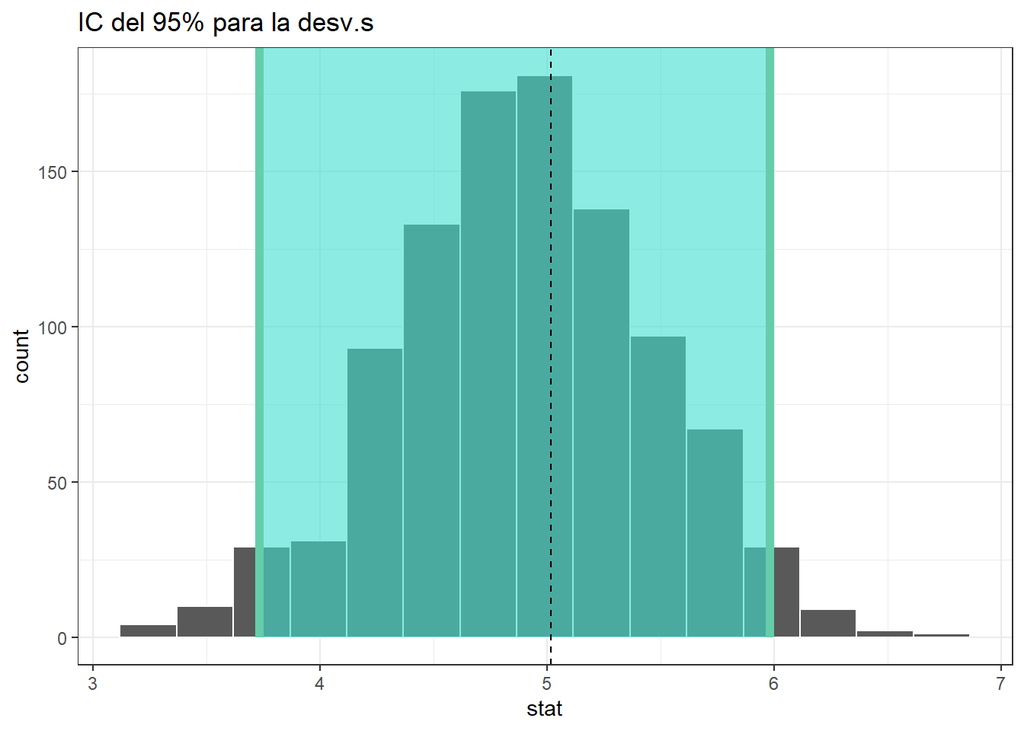

```r
estima.rep %>%
  visualise() +
  shade_ci(endpoints = ic_s_perc) +
  geom_vline(xintercept = estima.s$stat, linetype = 2) +
  labs(title = "IC del 95% para la desv.s") + theme_bw()
```

#### ANOVA

Un análisis de las varianzas se puede obtener como

```r
glimpse(datadp)
```

```
## Rows: 40
## Columns: 4
## $ Cond      <chr> "Cond1", "Cond2", "Cond1", "Cond2", "Cond1", "Cond2", "Cond1…
## $ tiempo    <dbl> 55.6, 55.1, 56.1, 43.5, 61.8, 51.2, 55.9, 46.2, 51.4, 56.7, …
## $ Condicion <fct> 1, 2, 1, 2, 1, 2, 1, 2, 1, 2, 1, 2, 1, 2, 1, 2, 1, 2, 1, 2, …
## $ x         <fct> Tiempo>50, Tiempo>50, Tiempo>50, Tiempo<=50, Tiempo>50, Tiem…
```

```r
set.seed(12345)
data2 <- datadp %>%
       mutate(cat = factor(ifelse(runif(nrow(datadp)) <0.33,1, ifelse(runif(nrow(datadp)) <0.66,2, 3))))

res <- data2 %>%
       specify(formula = tiempo ~ cat) %>%
       generate(reps = 1000, type = "bootstrap") %>%        calculate(stat = "F")
```

Observado, puede comparar su resultado con el análisis de varianza usando `aov`.

```r
Fobs <- data2 %>%
        observe(tiempo ~ cat, stat = "F")
```

```r
ic_aov_perc <- res %>%
            get_ci(type = "percentile", level = 0.95)
```

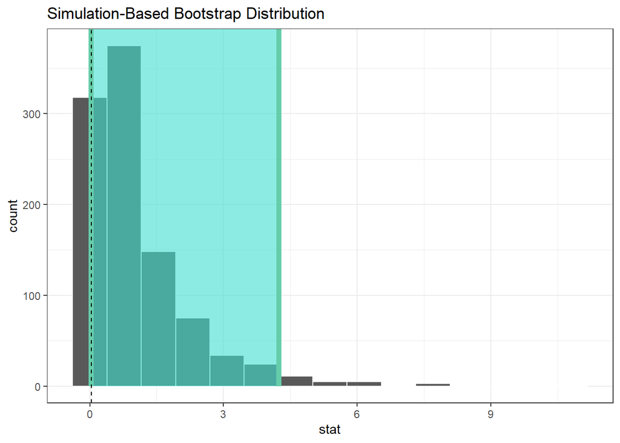

```r
res %>%
  visualise() +
  shade_ci(endpoints = ic_aov_perc) +
  geom_vline(xintercept = Fobs$stat, linetype = 2) + theme_bw()
```